# Equação do melhorista com os dados: tempo e seleção indireta na HTP

Cristhian Milbradt Babeski, PPGA/UFSM

09/10/2026

## 1 Equação

$$\Delta G = \frac{i \cdot r \cdot
\sigma_G}{L}$$

| Termo | O que é | O que a HTP faz |
| --- | --- | --- |
| **L** | anos por ciclo | encurta se a decisão com o índice substituir uma etapa |
| **r** | acurácia do critério | seleção indireta: $r = H \cdot r_G$ |
| **i** | intensidade de seleção | sobe se mais genótipos forem avaliados |
| **σG** | variação genotípica | não muda |

Aqui $H$ é a raiz da herdabilidade em sentido amplo ($H^2$) e $\sigma_G$ o desvio-padrão genotípico: sem pedigree não há herdabilidade restrita ($h^2$) nem $\sigma_A$, e para seleção entre linhagens a $H^2$ é a que governa a resposta. Seleção indireta pelo índice $x$ no lugar do rendimento $y$, com a mesma intensidade: $CR_y/R_y = (H_x/H_y) \cdot r_G$. Fontes: Lush (1937); Falconer e Mackay (1996); Cobb et al. (2019).

## 2 Banco (simulado)

48 genótipos, 2 safras, 3 blocos, 6 voos. R, G e B são as médias das bandas na parcela (0 a 255).

```r
head(dados)
```

```
## # A tibble: 6 × 8
##   genotipo   ano bloco rendimento   voo     R     G     B
##   <chr>    <dbl> <dbl>      <dbl> <dbl> <dbl> <dbl> <dbl>
## 1 G01       2024     1       3681     1  85.1  148.  74.5
## 2 G01       2024     1       3681     2  79.2  145.  77.2
## 3 G01       2024     1       3681     3  71.7  150.  74.8
## 4 G01       2024     1       3681     4  77.7  148.  74.4
## 5 G01       2024     1       3681     5  71.4  161.  73.4
## 6 G01       2024     1       3681     6  69.9  150.  72
```

## 3 Índice de imagem

```r
dados$NGRDI <- (dados$G - dados$R) / (dados$G + dados$R)
dados$GLI   <- ((dados$G - dados$R) + (dados$G - dados$B)) / (dados$G + dados$R + dados$G + dados$B)
dados$VARI  <- (dados$G - dados$R) / (dados$G + dados$R - dados$B)
indice_usado <- "GLI"                     # trocar aqui muda o relatório inteiro
dados$indice <- dados[[indice_usado]]
```

| Índice | Fórmula |
| --- | --- |
| NGRDI | (G − R) / (G + R) |
| GLI | ((G − R) + (G − B)) / (G + R + G + B) |
| VARI | (G − R) / (G + R − B) |

Índice usado: **GLI**.

## 4 r do método convencional

H² na média de genótipos por modelo misto; acurácia = raiz de H² (Cruz; Regazzi; Carneiro, 2012).

```r
parc <- unique(dados[c("genotipo", "ano", "bloco", "rendimento")])
H2_conv <- ajusta(parc, "rendimento")
r_conv  <- sqrt(H2_conv)
c(H2 = H2_conv, r = r_conv)
```

```
##        H2         r
## 0.6939062 0.8330103
```

## 5 r da HTP: seleção indireta

$r = H \cdot r_G$, com $H$ a raiz da herdabilidade do índice e $r_G$ a correlação genotípica entre índice e rendimento (correlação das médias de genótipos corrigida pelas herdabilidades).

```r
r_htp <- function(k, ind = "indice") {
  x  <- subset(dados, voo <= k)
  d  <- aggregate(list(indice = x[[ind]]), x[c("genotipo", "ano", "bloco")], mean)   # média dos k voos por parcela
  H2 <- ajusta(d, "indice")
  rp <- cor(tapply(d$indice, d$genotipo, mean), tapply(parc$rendimento, parc$genotipo, mean))
  rg <- min(rp / sqrt(H2 * H2_conv), 1)
  c(H2_indice = H2, rg = rg, r = sqrt(H2) * rg)
}
htp <- rbind("1 voo" = r_htp(1), "todos os voos" = r_htp(max(dados$voo)))
round(htp, 2)
```

```
##               H2_indice   rg    r
## 1 voo              0.83 0.63 0.58
## todos os voos      0.82 0.64 0.58
```

```r
r_h <- htp["todos os voos", "r"]
```

Voos da mesma safra repetem o erro de parcela: o limite de r é a rg, não o número de voos.

```r
round(t(sapply(c("NGRDI", "GLI", "VARI"), function(x) r_htp(max(dados$voo), x))), 2)   # comparação dos índices
```

```
##       H2_indice   rg    r
## NGRDI      0.82 0.63 0.57
## GLI        0.82 0.64 0.58
## VARI       0.81 0.63 0.57
```

```r
CRy_Ry <- r_h / r_conv      # com a mesma intensidade de seleção e o mesmo ciclo
round(c(r_conv = r_conv, r_htp = r_h, CRy_Ry = CRy_Ry), 2)
```

```
## r_conv  r_htp CRy_Ry
##   0.83   0.58   0.70
```

Selecionar pelo índice entrega **70%** do ganho da seleção direta. Os 30% restantes têm de vir do ciclo (L) ou do número de genótipos (i).

## 6 Voo a voo: herdabilidade, CV e acurácia

Cada voo é analisado sozinho, com o mesmo modelo. **H²** é a herdabilidade do índice na média de genótipos, **CVg** o coeficiente de variação genotípico, **CVe** o do erro e **CVg/CVe** a razão entre eles (quanto maior, mais variação genética em relação ao ruído). A acurácia é $r = H \cdot r_G$.

```r
H2_y <- comp(parc, "rendimento")
r_voo <- function(k) {
  d  <- subset(dados, voo == k)[c("genotipo", "ano", "bloco", "indice")]
  cc <- comp(d, "indice")
  rp <- cor(tapply(d$indice, d$genotipo, mean), tapply(parc$rendimento, parc$genotipo, mean))
  rg <- min(rp / sqrt(cc["H2"] * H2_y["H2"]), 1)
  c(voo = k, H2 = unname(cc["H2"]), CVg = unname(cc["CVg"]), CVe = unname(cc["CVe"]),
    CVg_CVe = unname(cc["CVg"] / cc["CVe"]), rg = unname(rg), r = unname(sqrt(cc["H2"]) * rg))
}
voos <- as.data.frame(t(sapply(sort(unique(dados$voo)), r_voo)))
round(rbind(rendimento = c(voo = NA, H2 = H2_y[["H2"]], CVg = H2_y[["CVg"]], CVe = H2_y[["CVe"]], CVg_CVe = H2_y[["CVg"]] / H2_y[["CVe"]], rg = 1, r = sqrt(H2_y[["H2"]])), voos), 2)
```

```
##   voo   H2   CVg   CVe CVg_CVe   rg    r
## 1  NA 0.69  9.84 11.25    0.87 1.00 0.83
## 2   1 0.83 35.13 34.45    1.02 0.63 0.58
## 3   2 0.80 32.53 35.28    0.92 0.63 0.56
## 4   3 0.78 29.32 31.52    0.93 0.60 0.53
## 5   4 0.78 32.54 35.76    0.91 0.67 0.59
## 6   5 0.73 31.48 36.83    0.85 0.69 0.59
## 7   6 0.69 25.19 29.61    0.85 0.65 0.54
```

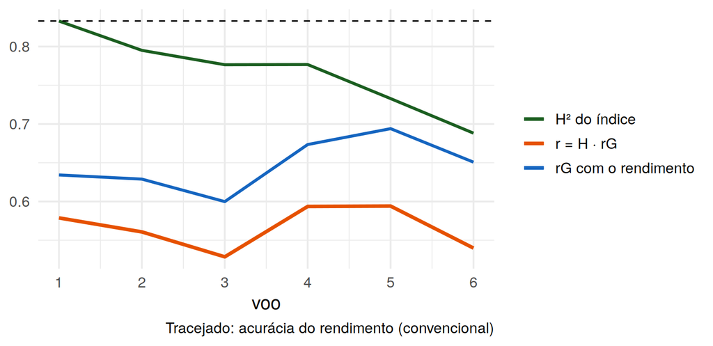

```r
ggplot(voos, aes(voo)) +
  geom_line(aes(y = H2, colour = "H² do índice"), linewidth = 1) + geom_line(aes(y = rg, colour = "rG com o rendimento"), linewidth = 1) +
  geom_line(aes(y = r, colour = "r = H · rG"), linewidth = 1.2) + geom_hline(yintercept = r_conv, linetype = 2) +
  scale_x_continuous(breaks = voos$voo) + scale_colour_manual(values = c("#1b5e20", "#e65100", "#1565c0")) +
  labs(x = "voo", y = NULL, colour = NULL, caption = "Tracejado: acurácia do rendimento (convencional)") + tema
```

Leitura: a H² do índice cai ao longo dos voos (0.83 no primeiro, 0.69 no último), a rG varia de 0.6 a 0.69, e o r fica numa faixa estreita (0.53 a 0.59). Diferenças desse tamanho entre voos não permitem ranqueá-los: escolher o melhor voo nos mesmos dados dá um r otimista, que precisa ser confirmado em outra safra. O CV do índice é alto porque a média dele é baixa (cerca de 0,18); serve para comparar voos entre si, não com o CV do rendimento.

## 7 Tempo: quanto o ciclo precisa encurtar

Com o mesmo i, ganho relativo da HTP = (r da HTP ÷ r convencional) ÷ (L da HTP ÷ L convencional).

```r
Lrel  <- c(1, 0.9, 0.75, 0.5)     # ciclo da HTP em fração do convencional
tempo <- data.frame(ciclo_HTP = Lrel, ganho_relativo_pct = round(100 * CRy_Ry / Lrel))
tempo
```

```
##   ciclo_HTP ganho_relativo_pct
## 1      1.00                 70
## 2      0.90                 78
## 3      0.75                 93
## 4      0.50                140
```

Empate com o mesmo i: ciclo da HTP em **0.7** do convencional, isto é, encurtamento mínimo de **30%**.

## 8 Genótipos: efeito sobre i

Capacidade de cada método (aba `custos`, valores hipotéticos), com 20 genótipos selecionados.

```r
data.frame(metodo = c("convencional", "HTP"), avaliados = c(N_conv, N_htp),
           i = round(c(i_sel(n_sel, N_conv), i_sel(n_sel, N_htp)), 2))
```

```
##         metodo avaliados    i
## 1 convencional       200 1.75
## 2          HTP       666 2.27
```

## 9 Cenários

Ganho relativo = (i × r / L) de cada cenário ÷ o do convencional, com σG igual.

```r
g <- function(N, r, L) i_sel(n_sel, N) * r / L
res <- data.frame(
  cenario   = c("A. Convencional", "B. HTP: só seleção indireta", "C. HTP: indireta + ciclo mais curto",
                "D. HTP: indireta + mais genótipos", "E. HTP: indireta + mais genótipos + ciclo mais curto"),
  avaliados = c(N_conv, N_conv, N_conv, N_htp, N_htp),
  r         = round(c(r_conv, r_h, r_h, r_h, r_h), 2),
  L         = c(L_conv, L_conv, L_htp, L_conv, L_htp))
res$i <- round(i_sel(n_sel, res$avaliados), 2)
res$ganho_relativo_pct <- round(100 * mapply(g, res$avaliados, res$r, res$L) / g(N_conv, r_conv, L_conv))
res[c("cenario", "avaliados", "i", "r", "L", "ganho_relativo_pct")]
```

```
##                                                cenario avaliados    i    r    L
## 1                                      A. Convencional       200 1.75 0.83 1.00
## 2                          B. HTP: só seleção indireta       200 1.75 0.58 1.00
## 3                  C. HTP: indireta + ciclo mais curto       200 1.75 0.58 0.75
## 4                    D. HTP: indireta + mais genótipos       666 2.27 0.58 1.00
## 5 E. HTP: indireta + mais genótipos + ciclo mais curto       666 2.27 0.58 0.75
##   ganho_relativo_pct
## 1                100
## 2                 70
## 3                 93
## 4                 90
## 5                120
```

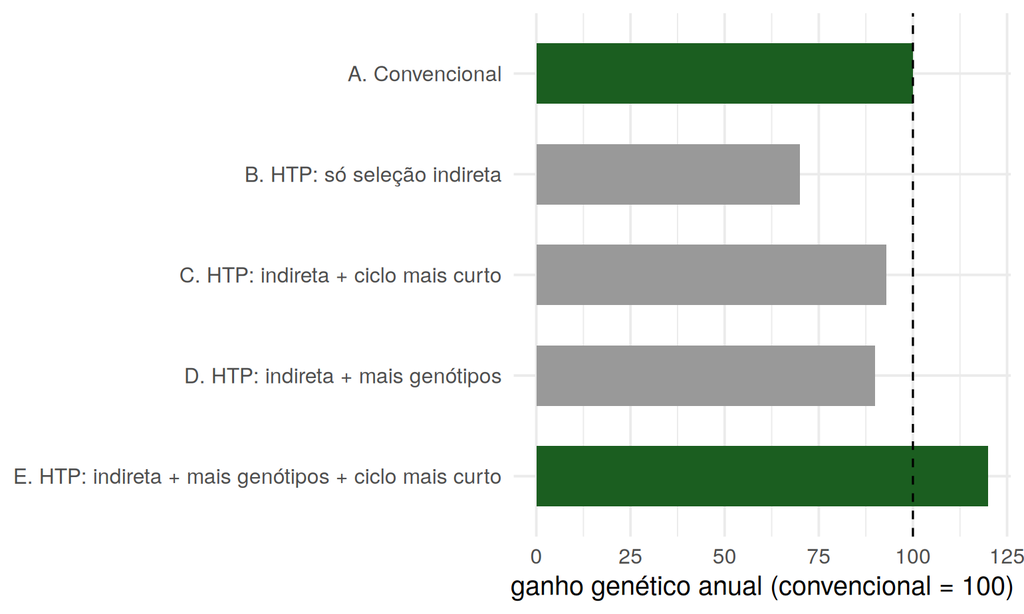

```r
ggplot(res, aes(factor(cenario, levels = rev(cenario)), ganho_relativo_pct, fill = ganho_relativo_pct >= 100)) +
  geom_col(width = 0.6, show.legend = FALSE) + geom_hline(yintercept = 100, linetype = 2) + coord_flip() +
  scale_fill_manual(values = c("grey60", "#1b5e20")) +
  labs(x = NULL, y = "ganho genético anual (convencional = 100)") + tema
```

Seleção indireta sozinha: 70%. Ciclo mais curto: 93%. Mais genótipos: 90%. Os dois juntos: 120%. O efeito de L é proporcional a 1/L; o de i tem retorno decrescente. Com mais genótipos e o mesmo ciclo, o r mínimo para empatar é 0.64.

## 10 Sensibilidade: r e ciclo

Ganho relativo com mais genótipos (N da HTP), por r e por ciclo. Acima da linha tracejada a HTP compensa.

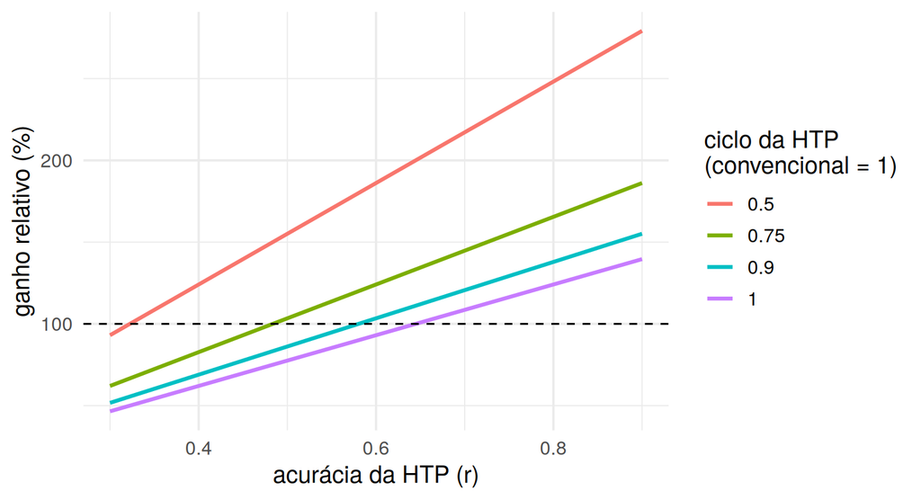

```r
v <- expand.grid(r = seq(0.3, 0.9, 0.01), Lrel = Lrel)
v$ganho <- 100 * mapply(function(r, Lr) g(N_htp, r, L_conv * Lr), v$r, v$Lrel) / g(N_conv, r_conv, L_conv)
ggplot(v, aes(r, ganho, colour = factor(Lrel))) + geom_line(linewidth = 1) + geom_hline(yintercept = 100, linetype = 2) +
  labs(x = "acurácia da HTP (r)", y = "ganho relativo (%)", colour = "ciclo da HTP\n(convencional = 1)") + tema
```

## 11 R², RMSE e MAE

Medem o ajuste na parcela, não a ordem das linhagens nem o tempo ganho. Para seleção, reportar também H² do índice, rg com o rendimento, acurácia por linhagem, coincidência do grupo selecionado e ganho anual relativo ao convencional (Fritsche-Neto et al., 2025; Roberts et al., 2017).

## 12 Produtividade predita pelo RGB como critério auxiliar

Além do índice, o critério auxiliar pode ser o **rendimento predito** por um modelo treinado nas bandas R, G e B (3 bandas × 6 voos = 18 preditoras). Cada genótipo é predito por um modelo treinado em outros genótipos (8 partes com genótipos inteiros de fora), depois de tirar o efeito de safra. Em cada critério, H², rG e r = H · rG são calculados na escala de genótipo. **r_verdadeiro** usa o valor genético da simulação (só existe no banco simulado).

```r
vd <- read_excel(arq, sheet = "verdade_simulada")
w <- reshape(as.data.frame(dados)[c("genotipo", "ano", "bloco", "voo", "R", "G", "B")], idvar = c("genotipo", "ano", "bloco"), timevar = "voo", direction = "wide")
w <- merge(w, as.data.frame(parc), by = c("genotipo", "ano", "bloco"))
X <- as.matrix(w[grep("^(R|G|B)\\.", names(w))]); y <- w$rendimento
X <- apply(X, 2, function(v) v - ave(v, w$ano)); y <- y - ave(y, w$ano)      # tira o efeito de safra
set.seed(1); gen <- unique(w$genotipo); fold <- setNames(sample(rep(1:8, length.out = length(gen))), gen)[w$genotipo]
mg <- tapply(parc$rendimento, parc$genotipo, mean)

avalia <- function(d, nome) {          # d: genotipo, ano, bloco, x (critério por parcela)
  hx <- ajusta(d, "x"); mx <- tapply(d$x, d$genotipo, mean)
  rg <- min(cor(mx[names(mg)], mg) / sqrt(hx * H2_conv), 1)
  data.frame(criterio = nome, H2 = hx, rG = rg, r = sqrt(hx) * rg, r_verdadeiro = cor(mx[vd$genotipo], vd$g_rendimento))
}
prever <- function(nome, fun, Xm = X) {
  w$x <- NA_real_
  for (k in 1:8) { tr <- fold != k; w$x[!tr] <- fun(Xm[tr, , drop = FALSE], y[tr], Xm[!tr, , drop = FALSE]) }
  avalia(w[c("genotipo", "ano", "bloco", "x")], nome)
}
```

```r
ridge <- function(Xt, yt, Xn) { m <- glmnet::cv.glmnet(scale(Xt), yt, alpha = 0)
  as.numeric(predict(m, scale(Xn, attr(scale(Xt), "scaled:center"), attr(scale(Xt), "scaled:scale")), s = "lambda.min")) }
floresta <- function(Xt, yt, Xn) predict(ranger::ranger(x = as.data.frame(Xt), y = yt, num.trees = 300, seed = 1), as.data.frame(Xn))$predictions
xgb <- function(Xt, yt, Xn) {
  m <- xgboost::xgb.train(params = list(objective = "reg:squarederror", eta = 0.05, max_depth = 3, subsample = 0.8, colsample_bytree = 0.8),
                          data = xgboost::xgb.DMatrix(Xt, label = yt), nrounds = 200, verbose = 0)
  predict(m, xgboost::xgb.DMatrix(Xn)) }
X3 <- sapply(c("R", "G", "B"), function(b) rowMeans(X[, grep(paste0("^", b, "\\."), colnames(X))]))
linear <- function(Xt, yt, Xn) predict(lm(yt ~ ., data = as.data.frame(Xt)), as.data.frame(Xn))

med <- function(ind) aggregate(list(x = dados[[ind]]), dados[c("genotipo", "ano", "bloco")], mean)
aux <- rbind(avalia(med("GLI"), "índice GLI (média dos voos)"),
             avalia(med("VARI"), "índice VARI (média dos voos)"),
             prever("ridge em R, G, B (18 preditoras)", ridge),
             prever("floresta aleatória em R, G, B", floresta),
             prever("regressão linear em R, G, B médios", linear, X3))
if (requireNamespace("xgboost", quietly = TRUE)) aux <- rbind(aux, prever("XGBoost em R, G, B (18 preditoras)", xgb))
aux$CRy_Ry <- aux$r / r_conv
base <- g(N_conv, r_conv, L_conv)
aux$so_ciclo_curto     <- 100 * g(N_conv, aux$r, L_htp)  / base
aux$mais_genotipos     <- 100 * g(N_htp,  aux$r, L_conv) / base
aux$genotipos_e_ciclo  <- 100 * g(N_htp,  aux$r, L_htp)  / base
cbind(criterio = aux$criterio, round(aux[-1], 2))
```

```
##                             criterio   H2   rG    r r_verdadeiro CRy_Ry
## 1        índice GLI (média dos voos) 0.82 0.64 0.58         0.68   0.70
## 2       índice VARI (média dos voos) 0.81 0.63 0.57         0.66   0.68
## 3   ridge em R, G, B (18 preditoras) 0.81 0.42 0.38         0.52   0.45
## 4      floresta aleatória em R, G, B 0.81 0.39 0.35         0.49   0.42
## 5 regressão linear em R, G, B médios 0.82 0.45 0.40         0.54   0.49
##   so_ciclo_curto mais_genotipos genotipos_e_ciclo
## 1          93.13          90.25            120.33
## 2          91.07          88.25            117.67
## 3          60.08          58.22             77.63
## 4          55.91          54.18             72.24
## 5          64.71          62.71             83.61
```

O rendimento medido (convencional) tem H² = 0.69, r = 0.83; ganho relativo = 100 por definição. As três últimas colunas são o ganho anual relativo, como nos cenários da seção 9.

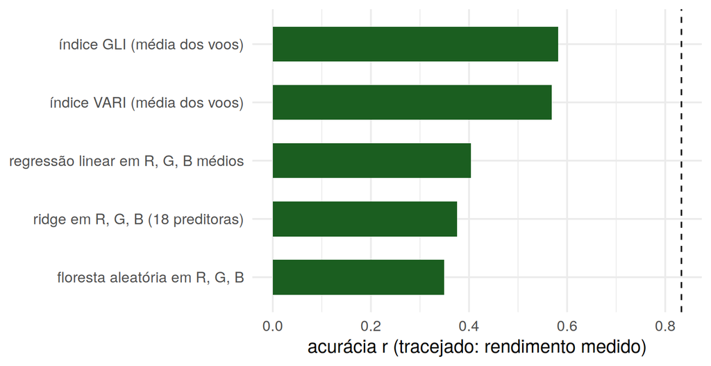

```r
ggplot(aux, aes(reorder(criterio, r), r)) + geom_col(fill = "#1b5e20", width = 0.6) + coord_flip() +
  geom_hline(yintercept = r_conv, linetype = 2) + labs(x = NULL, y = "acurácia r (tracejado: rendimento medido)") + tema
```

Leitura: os modelos de predição têm H² alta (são repetíveis), mas rG baixa, e por isso o r fica abaixo do índice simples. Os índices (razões entre bandas) já cancelam a variação de brilho entre voos, o que um modelo treinado em bandas cruas só aprende com muitos genótipos. Com poucos genótipos de treino e rendimento de parcela com muito ruído, a predição soma erro de estimação ao critério. Com dados reais, o resultado pode ser outro; a comparação deve ser feita com validação por genótipo, como acima.

## Referências

COBB, J. N. et al. Enhancing the rate of genetic gain in public-sector plant breeding programs: lessons from the breeder’s equation. Theoretical and Applied Genetics, v. 132, n. 3, p. 627-645, 2019.

CRUZ, C. D.; REGAZZI, A. J.; CARNEIRO, P. C. S. Modelos biométricos aplicados ao melhoramento genético. 4. ed. Viçosa, MG: UFV, 2012. v. 1.

FALCONER, D. S.; MACKAY, T. F. C. Introduction to quantitative genetics. 4. ed. Harlow: Longman, 1996.

FRITSCHE-NETO, R. et al. Prediction-based breeding: modern tools to optimize and reshape programs. Crop Science, v. 65, n. 5, art. e70175, 2025.

LUSH, J. L. Animal breeding plans. Ames: Iowa State College Press, 1937.

ROBERTS, D. R. et al. Cross-validation strategies for data with temporal, spatial, hierarchical, or phylogenetic structure. Ecography, v. 40, n. 8, p. 913-929, 2017.